# R Notebook

# Corrlation

What is correlation - relationship between two variables (positive or negative correlation) Both variables need to be ordered in some way

```r
library(ggfortify)
```

```r
mtcars %>%
  select(wt, mpg) %>%
  glimpse()
```

```
Rows: 32
Columns: 2
$ wt  <dbl> 2.620, 2.875, 2.320, 3.215, 3.440, 3.460, 3.570, 3.190, 3.150, 3.440, 3.440, 4.070, 3.730, 3.780, 5.250, 5.424, 5.~
$ mpg <dbl> 21.0, 21.0, 22.8, 21.4, 18.7, 18.1, 14.3, 24.4, 22.8, 19.2, 17.8, 16.4, 17.3, 15.2, 10.4, 10.4, 14.7, 32.4, 30.4, ~
```

[figure not shown]

Pearson’s r - measures the linear relationship between two variables - goes from -1 to +1 ()

```r
noisy_bivariate <- function(noise = 1, gradient = 1){
  x <- runif(n = 200, min = 0, max = 10)
  y <- gradient * x + 10
  y_scatter <- noise * 4 * rnorm(n = 200)
  y <- y + y_scatter
  data = tibble(x, y)

  r <- round(cor(x, y), 4)
  title <- paste(
    "noise = ", noise,
    ", gradient = ", gradient,
    ", r = ", r
  )

  data %>%
    ggplot(aes(x = x, y = y)) +
    geom_point() +
    xlim(0, 10) +
    ylim(min(c(min(y), 0)), max(c(max(y), 10))) +
    ggtitle(title)

}
noisy_bivariate(noise = 0, gradient = 0)
```

[output not shown]

[output not shown]

Remember to visualise your data before you run a correlation

|  | x1 | x2 | x3 | x4 | y1 | y2 | y3 | y4 |
| --- | --- | --- | --- | --- | --- | --- | --- | --- |
| 1 | 10 | 10 | 10 | 8 | 8.04 | 9.14 | 7.46 | 6.58 |
| 2 | 8 | 8 | 8 | 8 | 6.95 | 8.14 | 6.77 | 5.76 |
| 3 | 13 | 13 | 13 | 8 | 7.58 | 8.74 | 12.74 | 7.71 |

```r
# Pivot longer:
anscombe_long <- anscombe %>%
pivot_longer(everything(),
names_to = c(".value", "set"),
names_pattern = c("(\\D+)(\\d+)"))

# Group by set and get the correlation coefficient for each:
anscombe_long %>%
group_by(set) %>%
summarise(r = cor(x, y))
```

| set | r |
| --- | --- |
| 1 | 0.8164205 |
| 2 | 0.8162365 |
| 3 | 0.8162867 |
| 4 | 0.8165214 |

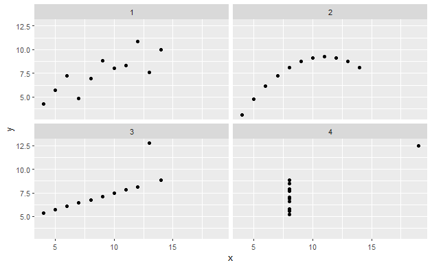

```r
# Plot the quartet:
anscombe_long %>%
ggplot() +
aes(x = x, y = y) +
geom_point() +
facet_wrap(~set)
```

## Task - 10 minutes

Now calculate the four correlation coefficients between the data pairs plotted above (x1 with y1 and so on). The data can be found in the built-in anscombe dataset. What do you notice about the correlation coefficients? Looking at each plot, think about whether the resulting coefficient accurately represents the pattern in the data.

| cor(x4, y4) |
| --- |
| 0.8165214 |

## Task - 15 mins Let’s calculate correlation coefficients for various variables in the state.x77 dataset!

Examine the contents of this dataset (try accessing documentation via ?state.x77 or running summary() on it). Choose a few combinations of variables to plot as y y versus x x and calculate the correlation coefficients for the same combinations. Do you find any strong correlations? Have a think about what kind of evidence you would need to be able to claim that any of the correlations you find are due to a causal relationship between the variables. [Hint the dataset is a matrix so convert it to a tibble first via tibble_states <- clean_names(as_tibble(state.x77)) to make manipulations easier].

| population | income | illiteracy | life_exp | murder | hs_grad | frost | area |
| --- | --- | --- | --- | --- | --- | --- | --- |
| 3615 | 3624 | 2.1 | 69.05 | 15.1 | 41.3 | 20 | 50708 |
| 365 | 6315 | 1.5 | 69.31 | 11.3 | 66.7 | 152 | 566432 |
| 2212 | 4530 | 1.8 | 70.55 | 7.8 | 58.1 | 15 | 113417 |
| 2110 | 3378 | 1.9 | 70.66 | 10.1 | 39.9 | 65 | 51945 |
| 21198 | 5114 | 1.1 | 71.71 | 10.3 | 62.6 | 20 | 156361 |
| 2541 | 4884 | 0.7 | 72.06 | 6.8 | 63.9 | 166 | 103766 |
| 3100 | 5348 | 1.1 | 72.48 | 3.1 | 56.0 | 139 | 4862 |
| 579 | 4809 | 0.9 | 70.06 | 6.2 | 54.6 | 103 | 1982 |
| 8277 | 4815 | 1.3 | 70.66 | 10.7 | 52.6 | 11 | 54090 |
| 4931 | 4091 | 2.0 | 68.54 | 13.9 | 40.6 | 60 | 58073 |

[output cut: 40 more lines]

| cor(income, illiteracy) |
| --- |
| -0.4370752 |

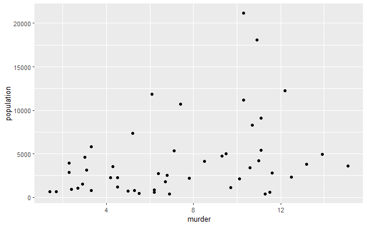

```r
tibble_states %>%
  ggplot(aes(x = murder,
             y = population))+
  geom_point()
```

```r
tibble_states %>%
  summarise(cor(murder, population))
```

| cor(murder, population) |
| --- |
| 0.3436428 |

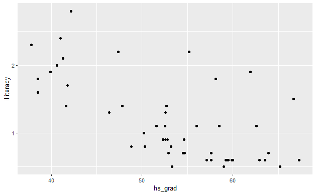

```r
tibble_states %>%
  ggplot(aes(x = hs_grad,
             y = illiteracy))+
  geom_point()
```

```r
tibble_states %>%
  summarise(cor(hs_grad, illiteracy))
```

| cor(hs_grad, illiteracy) |
| --- |
| -0.6571886 |

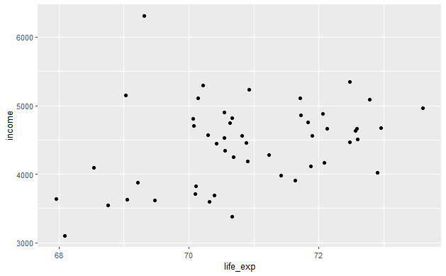

```r
tibble_states %>%
  ggplot(aes(x = life_exp,
             y = income))+
  geom_point()
```

```r
tibble_states %>%
  summarise(cor(life_exp, income))
```

| cor(life_exp, income) |
| --- |
| 0.3402553 |

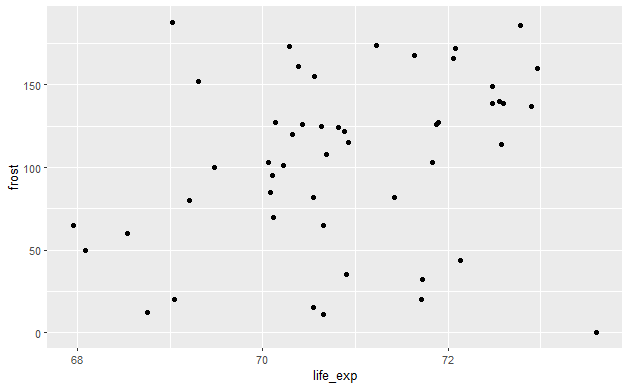

```r
tibble_states %>%
  ggplot(aes(x = life_exp,
             y = frost))+
  geom_point()
```

```r
tibble_states %>%
  summarise(cor(life_exp, frost))
```

| cor(life_exp, frost) |
| --- |
| 0.262068 |

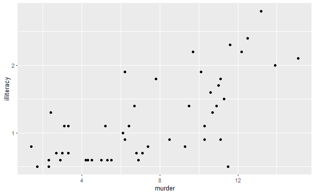

```r
tibble_states %>%
  ggplot(aes(x = murder,
             y = illiteracy))+
  geom_point()
```

```r
tibble_states %>%
  summarise(cor(murder, illiteracy))
```

| cor(murder, illiteracy) |
| --- |
| 0.7029752 |

# Creating the line of best fit

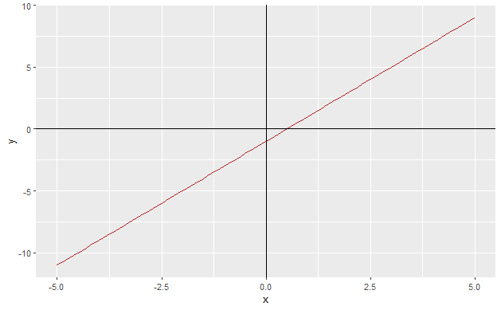

```r
line <- function(x, a, b){
  return(a * x + b)
}

data <- tibble(
  x = seq(-5, 5, 0.1),
  y = line(x, a = 2, b = -1)
)

data %>%
  ggplot(aes(x, y)) +
  geom_line(col = "firebrick") +
  geom_vline(xintercept = 0) +
  geom_hline(yintercept = 0)
```

## Task - 5 mins

Play around plotting two or three different lines. Try a line with a=0 a=0 and positive b. You can use mutate() to overwrite y in data from above Can we use our line() function to plot a perfectly vertical line?

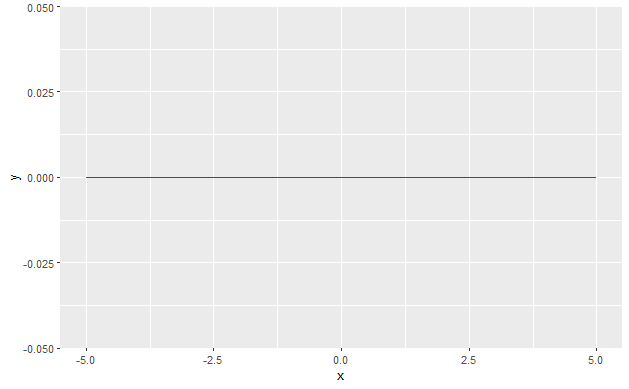

```r
data <- tibble(
  x = seq(-5, 5, 0.1),
  y = line(x, a = 0, b = 0)
)

data %>%
  ggplot(aes(x, y)) +
  geom_line(col = "firebrick") #+
```

```r
 # geom_vline(xintercept = 0) +
 # geom_hline(yintercept = 0)
```

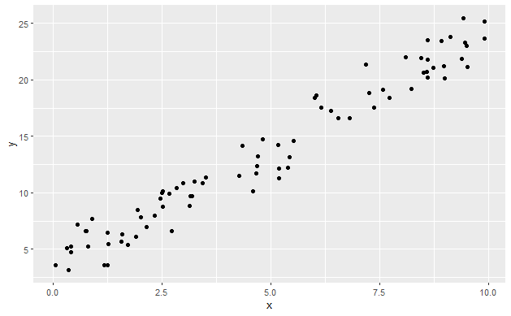

```r
noisy_line <- read_csv("data/noisy_line.csv")
noisy_line_plot <- noisy_line %>%
  ggplot(aes(x, y)) +
  geom_point()
noisy_line_plot
```

```r
centroid <- noisy_line %>%
  summarise(x = mean(x),
            y = mean(y))
centroid
```

| x | y |
| --- | --- |
| 4.806482 | 13.44237 |

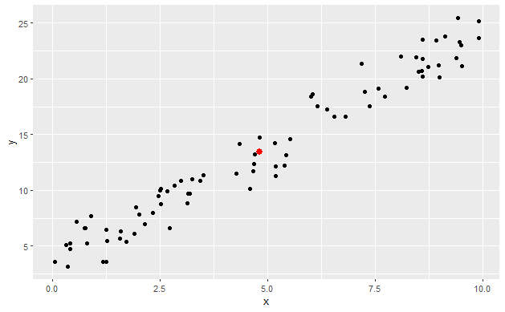

```r
noisy_line_plot <- noisy_line_plot +
  geom_point(aes(x = centroid$x, y = centroid$y),
             col = "red", size = 3)
noisy_line_plot
```

```r
get_intercept <- function(slope, centroid_x, centroid_y){
  return(centroid_y - slope * centroid_x)
}
```

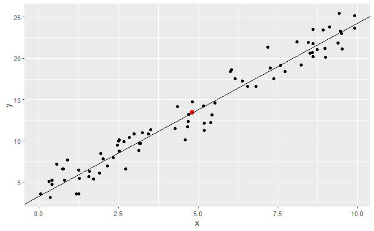

```r
slope = 2.1
noisy_line_plot +
  geom_abline(slope = slope, intercept = get_intercept(
    slope,
    centroid$x,
    centroid$y
  ))
```

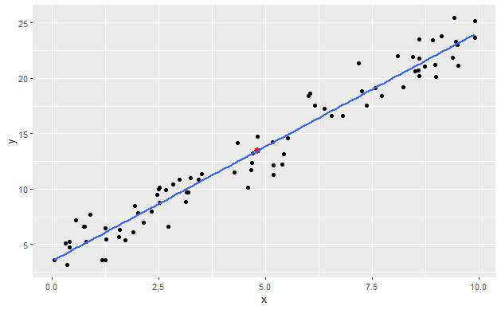

```r
noisy_line_plot +
  geom_smooth(method = "lm", se = FALSE)
```

Principle of parsimony Occam’s razor - given two or more explanations of comparable quality, the simplest explanation is the best one

# Linear regression

Explanatory / Independent / Predictor variable(s) Outcome / Dependent / Response variable

## Simple linear regression

Fit a straight line relationship between one predictor variable with a response.

```r
height <- c(176, 164, 181, 168, 195, 185, 166, 180, 188, 174)
weight <- c(82, 65, 85, 76, 90, 92, 68, 83, 94, 74)
```

```r
sample <- tibble(
  weight,
  height
)
```

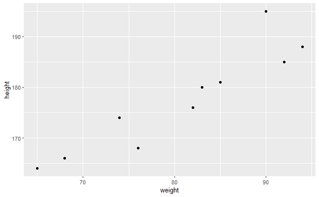

```r
line <- function(x, b0, b1){
  return(b0 + x * b1)
}
```

```r
b0 <- 95
b1 <- 1

sample <- sample %>%
  mutate(fitted_height = line(x = weight,
                              b0 = b0,
                              b1 = b1))
```

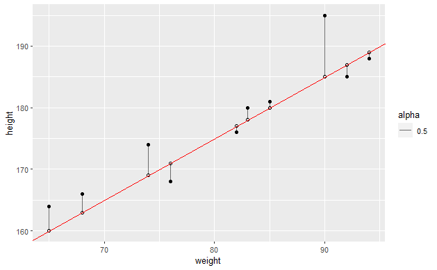

```r
sample %>%
  ggplot(aes(x = weight,
             y = height)) +
  geom_point() +
  geom_point(aes(y = fitted_height), shape = 1) +
  geom_abline(slope = b1, intercept = b0, col = "red") +
  geom_segment(aes(xend = weight, yend = fitted_height,
                   alpha = 0.5))
```

```r
sample <- sample %>%
  mutate(residual = height - fitted_height)

sample
```

| weight | height | fitted_height | residual |
| --- | --- | --- | --- |
| 82 | 176 | 177 | -1 |
| 65 | 164 | 160 | 4 |
| 85 | 181 | 180 | 1 |
| 76 | 168 | 171 | -3 |
| 90 | 195 | 185 | 10 |
| 92 | 185 | 187 | -2 |
| 68 | 166 | 163 | 3 |
| 83 | 180 | 178 | 2 |
| 94 | 188 | 189 | -1 |
| 74 | 174 | 169 | 5 |

```r
sample %>%
  summarise(sun_residuals = sum(residual))
```

| sun_residuals |
| --- |
| 18 |

```r
sample <- sample %>%
  mutate(sq_resid = residual ^ 2)
sample
```

| weight | height | fitted_height | residual | sq_resid |
| --- | --- | --- | --- | --- |
| 82 | 176 | 177 | -1 | 1 |
| 65 | 164 | 160 | 4 | 16 |
| 85 | 181 | 180 | 1 | 1 |
| 76 | 168 | 171 | -3 | 9 |
| 90 | 195 | 185 | 10 | 100 |
| 92 | 185 | 187 | -2 | 4 |
| 68 | 166 | 163 | 3 | 9 |
| 83 | 180 | 178 | 2 | 4 |
| 94 | 188 | 189 | -1 | 1 |
| 74 | 174 | 169 | 5 | 25 |

```r
sample %>%
  summarise(sun_sq_resid = sum(sq_resid))
```

| sun_sq_resid |
| --- |
| 170 |

```r
model <- lm(formula = height ~ weight,
            data = sample)
model
```

```
Call:
lm(formula = height ~ weight, data = sample)

Coefficients:
(Intercept)       weight
   102.1758       0.9336
```

```r
fitted(model)
```

```
       1        2        3        4        5        6        7        8        9       10
178.7269 162.8565 181.5276 173.1256 186.1953 188.0624 165.6572 179.6605 189.9295 171.2585
```

```r
model %>%
  predict(newdata = data.frame(weight = c(78)))
```

```
       1
174.9927
```

```r
sample <- sample %>%
  select(-c(fitted_height, residual, sq_resid)) %>%
  add_predictions(model) %>%
  add_residuals(model)

sample
```

| weight | height | pred | resid |
| --- | --- | --- | --- |
| 82 | 176 | 178.7269 | -2.7269054 |
| 65 | 164 | 162.8565 | 1.1434504 |
| 85 | 181 | 181.5276 | -0.5275564 |
| 76 | 168 | 173.1256 | -5.1256033 |
| 90 | 195 | 186.1953 | 8.8046919 |
| 92 | 185 | 188.0624 | -3.0624088 |
| 68 | 166 | 165.6572 | 0.3427994 |
| 83 | 180 | 179.6605 | 0.3395443 |
| 94 | 188 | 189.9295 | -1.9295095 |
| 74 | 174 | 171.2585 | 2.7414974 |

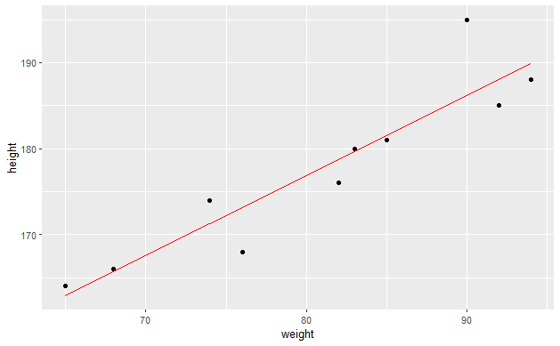

```r
sample %>%
  ggplot(aes(x = weight)) +
  geom_point(aes(y = height)) +
  geom_line(aes(y = pred), col = "red")
```

```r
weights_predict <- tibble(
  weight = 50:120
)

weights_predict %>%
  add_predictions(model)
```

| weight | pred |
| --- | --- |
| 50 | 148.8533 |
| 51 | 149.7868 |
| 52 | 150.7204 |
| 53 | 151.6539 |
| 54 | 152.5875 |
| 55 | 153.5210 |
| 56 | 154.4546 |
| 57 | 155.3881 |
| 58 | 156.3217 |
| 59 | 157.2552 |

[output cut: 61 more lines]

# Regression diagnostics

```r
sample %>%
  select(-c(pred, resid))
```

| weight | height |
| --- | --- |
| 82 | 176 |
| 65 | 164 |
| 85 | 181 |
| 76 | 168 |
| 90 | 195 |
| 92 | 185 |
| 68 | 166 |
| 83 | 180 |
| 94 | 188 |
| 74 | 174 |

```r
summary(model)
```

```
Call:
lm(formula = height ~ weight, data = sample)

Residuals:
    Min      1Q  Median      3Q     Max
-5.1256 -2.5276 -0.0940  0.9433  8.8047

Coefficients:
            Estimate Std. Error t value Pr(>|t|)
(Intercept) 102.1758    11.1541   9.160 1.63e-05 ***
weight        0.9336     0.1369   6.817 0.000135 ***
---
Signif. codes:  0 ‘***’ 0.001 ‘**’ 0.01 ‘*’ 0.05 ‘.’ 0.1 ‘ ’ 1

Residual standard error: 4.088 on 8 degrees of freedom
Multiple R-squared:  0.8531,    Adjusted R-squared:  0.8348
F-statistic: 46.47 on 1 and 8 DF,  p-value: 0.0001355
```

```r
model %>% tidy()
```

| term | estimate | std.error | statistic | p.value |
| --- | --- | --- | --- | --- |
| (Intercept) | 102.1757773 | 11.1541314 | 9.160353 | 1.627189e-05 |
| weight | 0.9335503 | 0.1369466 | 6.816893 | 1.354712e-04 |

```r
glance_output <- model %>%
  glance() %>%
  clean_names()
glance_output
```

| r_squared | adj_r_squared | sigma | statistic | p_value | df | log_lik | aic | bic | deviance | df_residual | nobs |
| --- | --- | --- | --- | --- | --- | --- | --- | --- | --- | --- | --- |
| 0.8531302 | 0.8347715 | 4.087575 | 46.47002 | 0.0001354712 | 1 | -27.15319 | 60.30637 | 61.21413 | 133.6662 | 8 | 10 |

```r
tidy_output <- model %>%
  tidy() %>%
  clean_names()
tidy_output
```

| term | estimate | std_error | statistic | p_value |
| --- | --- | --- | --- | --- |
| (Intercept) | 102.1757773 | 11.1541314 | 9.160353 | 1.627189e-05 |
| weight | 0.9335503 | 0.1369466 | 6.816893 | 1.354712e-04 |

```r
glance_output$r_squared
```

```
[1] 0.8531302
```

| cor(weight, height) |
| --- |
| 0.9236505 |

# Diagnostic plots

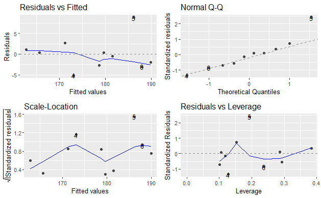

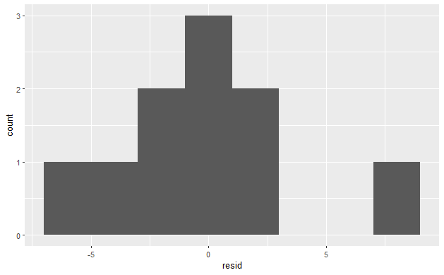

## Task - 15 min

We provide two data sets: distribution_1.csv and distribution_2.csv. Fitting a simple linear regression to each of these distributions leads to problems with the residuals for two different reasons. See if you can identify the problem in each case! Load the data set. 1) Fit a simple linear regression taking y as the outcome and x as the explanatory variable, saving the model object. 2) Check the diagnostic plots for the model object and identify the main problem you see with the residuals (use the autoplot() function). 3)Finally, plot the data and overlay the best fit line (use add_predictions() to add a pred column to the data set, and then plot via geom_point() and geom_line()). Does this plot help you interpret the problem you found in the residuals?

```r
dist_2 <- read_csv("data/distribution_2.csv") %>% clean_names()
```

```r
model_2 <- lm(formula = y ~ x,
              data = dist_2)
model_2
```

```
Call:
lm(formula = y ~ x, data = dist_2)

Coefficients:
(Intercept)            x
    20.2803       0.9955
```

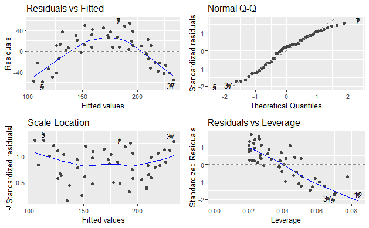

```r
model_1 %>%
  autoplot()
```

[figure not shown]

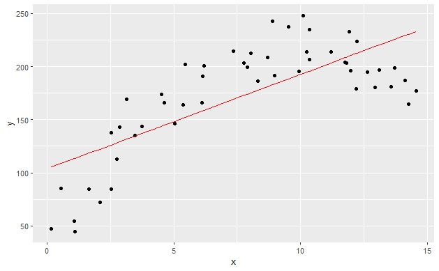

```r
dist_1 <- dist_1 %>%
  add_predictions(model_1) %>%
  add_residuals(model_1)

dist_1 %>%
  ggplot(aes(x = x)) +
  geom_point(aes(y = y)) +
  geom_line(aes(y = pred), col = "red")
```

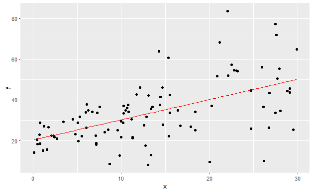

```r
dist_2 <- dist_2 %>%
  add_predictions(model_2) %>%
  add_residuals(model_2)

dist_2 %>%
  ggplot(aes(x = x)) +
  geom_point(aes(y = y)) +
  geom_line(aes(y = pred), col = "red")
```

# Bootstrapping regression

```r
library(infer)
```

```r
bootstrap_dist_slope <- dist_2 %>%
  specify(formula = y~x) %>%
  generate(reps = 10000, type = "bootstrap") %>%
  calculate(stat = "slope")

slope_ci95 <- bootstrap_dist_slope %>%
  get_ci(level = 0.95, type = "percentile")

slope_ci95
```

| lower_ci | upper_ci |
| --- | --- |
| 0.6924753 | 1.300434 |

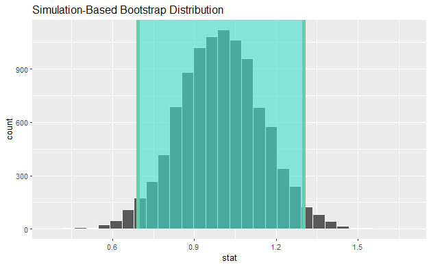

```r
bootstrap_dist_slope %>%
  visualise(bins = 30) +
  shade_ci(endpoints = slope_ci95)
```

| term | estimate | std_error | statistic | p_value | conf_low | conf_high |
| --- | --- | --- | --- | --- | --- | --- |
| (Intercept) | 20.2802947 | 2.3252755 | 8.721674 | 7.152345e-14 | 15.6658611 | 24.894728 |
| x | 0.9955266 | 0.1443214 | 6.897983 | 5.215480e-10 | 0.7091255 | 1.281928 |